# Using Predictive Modeling to Analyze Employee Churn

Frederick T. Williams

April 21, 2020

# Defining the Business Problem

Within the US, employers face an average employee churn of about 10%-15% annually which can prove costly to companies especially those in their early-stages of growth (Law, 2019). Kolowich (2018) wrote that when valued employees leave abruptly, it is estimated that it costs companies 30% from its other employees’ annual salary to hire junior employees. However, that percentage can be increased to 400% when replace more senior position roles (Kolowich, 2018).

For companies finding a replacement difficult because the company is trying to find someone who is as productive as their former employee. The company also must consider the loss of knowledge and business acumen about the company, and time and resources needed to teach the new hire. As a result, this process can be a serious problem for companies that are facing high rates of attrition due to the extra load management being placed on other employees (Ashe-Edmunds, 2017). However, many companies today try to resolve this issue by creating programs that provide training and career development, and improved work-life balance to boost employee retention (Regan, 2020).

The fact that employee churn has and will continue be an issue that companies face, within this data science project I will be creating an model with the IBM dataset, provided by [Kaggle](https://www.kaggle.com/pavansubhasht/ibm-hr-analytics-attrition-dataset). In this analysis, I hope to use this dataset to build a model to predict when employees are going to quit by understanding the main drivers of employee churn.

### Importing the data

Let’s import the dataset and make of a copy of the source file for this analysis.

```r
setwd("C:/Users/frede/OneDrive - Regis University/MSDS_696/MSDS696_Data_Science_Practicum_II/")

# Read Excel file
df_source <- read.csv("Data/WA_Fn-UseC_-HR-Employee-Attrition.csv")
names(df_source)
```

```
##  [1] "ï..Age"                   "Attrition"
##  [3] "BusinessTravel"           "DailyRate"
##  [5] "Department"               "DistanceFromHome"
##  [7] "Education"                "EducationField"
##  [9] "EmployeeCount"            "EmployeeNumber"
## [11] "EnvironmentSatisfaction"  "Gender"
## [13] "HourlyRate"               "JobInvolvement"
## [15] "JobLevel"                 "JobRole"
## [17] "JobSatisfaction"          "MaritalStatus"
## [19] "MonthlyIncome"            "MonthlyRate"
## [21] "NumCompaniesWorked"       "Over18"
## [23] "OverTime"                 "PercentSalaryHike"
## [25] "PerformanceRating"        "RelationshipSatisfaction"
## [27] "StandardHours"            "StockOptionLevel"
## [29] "TotalWorkingYears"        "TrainingTimesLastYear"
## [31] "WorkLifeBalance"          "YearsAtCompany"
## [33] "YearsInCurrentRole"       "YearsSinceLastPromotion"
## [35] "YearsWithCurrManager"
```

```r
colnames(df_source)[1] <- "Age" # Renaming the column
```

```r
# Making copy of the dataset
library(data.table)
HR_data <- copy(df_source)
```

### Exploratory Data Analysis

Let’s look at the data and see how it is formatted before performing analysis

```r
str(HR_data)
```

```
## 'data.frame':    1470 obs. of  35 variables:
##  $ Age                     : int  41 49 37 33 27 32 59 30 38 36 ...
##  $ Attrition               : Factor w/ 2 levels "No","Yes": 2 1 2 1 1 1 1 1 1 1 ...
##  $ BusinessTravel          : Factor w/ 3 levels "Non-Travel","Travel_Frequently",..: 3 2 3 2 3 2 3 3 2 3 ...
##  $ DailyRate               : int  1102 279 1373 1392 591 1005 1324 1358 216 1299 ...
##  $ Department              : Factor w/ 3 levels "Human Resources",..: 3 2 2 2 2 2 2 2 2 2 ...
##  $ DistanceFromHome        : int  1 8 2 3 2 2 3 24 23 27 ...
##  $ Education               : int  2 1 2 4 1 2 3 1 3 3 ...
##  $ EducationField          : Factor w/ 6 levels "Human Resources",..: 2 2 5 2 4 2 4 2 2 4 ...
##  $ EmployeeCount           : int  1 1 1 1 1 1 1 1 1 1 ...
##  $ EmployeeNumber          : int  1 2 4 5 7 8 10 11 12 13 ...
##  $ EnvironmentSatisfaction : int  2 3 4 4 1 4 3 4 4 3 ...
##  $ Gender                  : Factor w/ 2 levels "Female","Male": 1 2 2 1 2 2 1 2 2 2 ...
##  $ HourlyRate              : int  94 61 92 56 40 79 81 67 44 94 ...
##  $ JobInvolvement          : int  3 2 2 3 3 3 4 3 2 3 ...
```

[output cut: 21 more lines]

From the data, we can see that there are 1,470 observations and 35 variables with various information about the employees.

Now let us have a glimpse of the data but instead of using the `glimpse()` or `summary()` functions, lets use the `skim()` function. The reason why is because can provide more detail about the data, such as the missing rate, complete rate, and a mini histogram of each variable (Quinn & Waring, 2019).

```r
#install.packages('skimr')
library(skimr)
skim(HR_data)
```

Data summary

| Name | HR_data |
| --- | --- |
| Number of rows | 1470 |
| Number of columns | 35 |
| _______________________ |  |
| Column type frequency: |  |
| factor | 9 |
| numeric | 26 |
| ________________________ |  |
| Group variables | None |

**Variable type: factor**

| skim_variable | n_missing | complete_rate | ordered | n_unique | top_counts |
| --- | --- | --- | --- | --- | --- |
| Attrition | 0 | 1 | FALSE | 2 | No: 1233, Yes: 237 |
| BusinessTravel | 0 | 1 | FALSE | 3 | Tra: 1043, Tra: 277, Non: 150 |
| Department | 0 | 1 | FALSE | 3 | Res: 961, Sal: 446, Hum: 63 |
| EducationField | 0 | 1 | FALSE | 6 | Lif: 606, Med: 464, Mar: 159, Tec: 132 |
| Gender | 0 | 1 | FALSE | 2 | Mal: 882, Fem: 588 |
| JobRole | 0 | 1 | FALSE | 9 | Sal: 326, Res: 292, Lab: 259, Man: 145 |
| MaritalStatus | 0 | 1 | FALSE | 3 | Mar: 673, Sin: 470, Div: 327 |
| Over18 | 0 | 1 | FALSE | 1 | Y: 1470 |
| OverTime | 0 | 1 | FALSE | 2 | No: 1054, Yes: 416 |

**Variable type: numeric**

| skim_variable | n_missing | complete_rate | mean | sd | p0 | p25 | p50 | p75 | p100 | hist |
| --- | --- | --- | --- | --- | --- | --- | --- | --- | --- | --- |
| Age | 0 | 1 | 36.92 | 9.14 | 18 | 30.00 | 36.0 | 43.00 | 60 |  |
| DailyRate | 0 | 1 | 802.49 | 403.51 | 102 | 465.00 | 802.0 | 1157.00 | 1499 |  |
| DistanceFromHome | 0 | 1 | 9.19 | 8.11 | 1 | 2.00 | 7.0 | 14.00 | 29 |  |
| Education | 0 | 1 | 2.91 | 1.02 | 1 | 2.00 | 3.0 | 4.00 | 5 |  |
| EmployeeCount | 0 | 1 | 1.00 | 0.00 | 1 | 1.00 | 1.0 | 1.00 | 1 |  |
| EmployeeNumber | 0 | 1 | 1024.87 | 602.02 | 1 | 491.25 | 1020.5 | 1555.75 | 2068 |  |
| EnvironmentSatisfaction | 0 | 1 | 2.72 | 1.09 | 1 | 2.00 | 3.0 | 4.00 | 4 |  |
| HourlyRate | 0 | 1 | 65.89 | 20.33 | 30 | 48.00 | 66.0 | 83.75 | 100 |  |
| JobInvolvement | 0 | 1 | 2.73 | 0.71 | 1 | 2.00 | 3.0 | 3.00 | 4 |  |
| JobLevel | 0 | 1 | 2.06 | 1.11 | 1 | 1.00 | 2.0 | 3.00 | 5 |  |
| JobSatisfaction | 0 | 1 | 2.73 | 1.10 | 1 | 2.00 | 3.0 | 4.00 | 4 |  |
| MonthlyIncome | 0 | 1 | 6502.93 | 4707.96 | 1009 | 2911.00 | 4919.0 | 8379.00 | 19999 |  |
| MonthlyRate | 0 | 1 | 14313.10 | 7117.79 | 2094 | 8047.00 | 14235.5 | 20461.50 | 26999 |  |
| NumCompaniesWorked | 0 | 1 | 2.69 | 2.50 | 0 | 1.00 | 2.0 | 4.00 | 9 |  |
| PercentSalaryHike | 0 | 1 | 15.21 | 3.66 | 11 | 12.00 | 14.0 | 18.00 | 25 |  |
| PerformanceRating | 0 | 1 | 3.15 | 0.36 | 3 | 3.00 | 3.0 | 3.00 | 4 |  |
| RelationshipSatisfaction | 0 | 1 | 2.71 | 1.08 | 1 | 2.00 | 3.0 | 4.00 | 4 |  |
| StandardHours | 0 | 1 | 80.00 | 0.00 | 80 | 80.00 | 80.0 | 80.00 | 80 |  |
| StockOptionLevel | 0 | 1 | 0.79 | 0.85 | 0 | 0.00 | 1.0 | 1.00 | 3 |  |
| TotalWorkingYears | 0 | 1 | 11.28 | 7.78 | 0 | 6.00 | 10.0 | 15.00 | 40 |  |
| TrainingTimesLastYear | 0 | 1 | 2.80 | 1.29 | 0 | 2.00 | 3.0 | 3.00 | 6 |  |
| WorkLifeBalance | 0 | 1 | 2.76 | 0.71 | 1 | 2.00 | 3.0 | 3.00 | 4 |  |
| YearsAtCompany | 0 | 1 | 7.01 | 6.13 | 0 | 3.00 | 5.0 | 9.00 | 40 |  |
| YearsInCurrentRole | 0 | 1 | 4.23 | 3.62 | 0 | 2.00 | 3.0 | 7.00 | 18 |  |
| YearsSinceLastPromotion | 0 | 1 | 2.19 | 3.22 | 0 | 0.00 | 1.0 | 3.00 | 15 |  |
| YearsWithCurrManager | 0 | 1 | 4.12 | 3.57 | 0 | 2.00 | 3.0 | 7.00 | 17 |  |

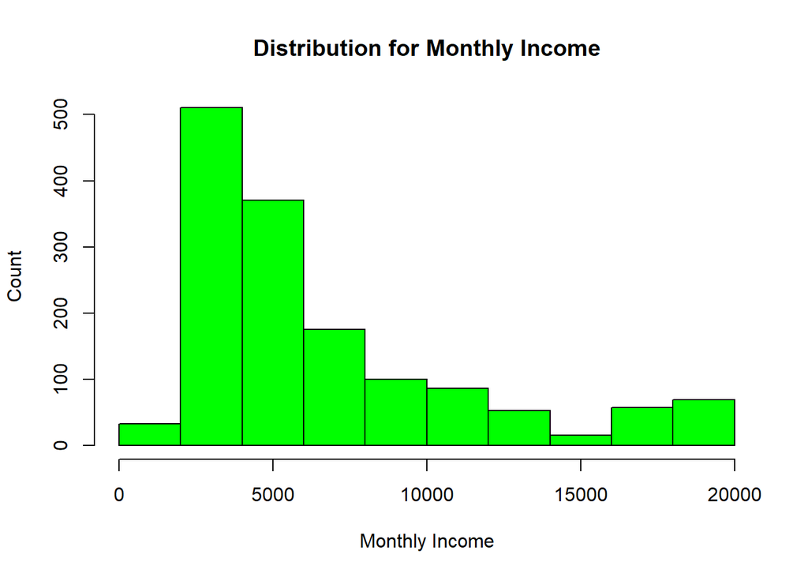

```r
hist(HR_data$MonthlyIncome,main="Distribution for Monthly Income",xlab="Monthly Income",ylab="Count",col="green")
```

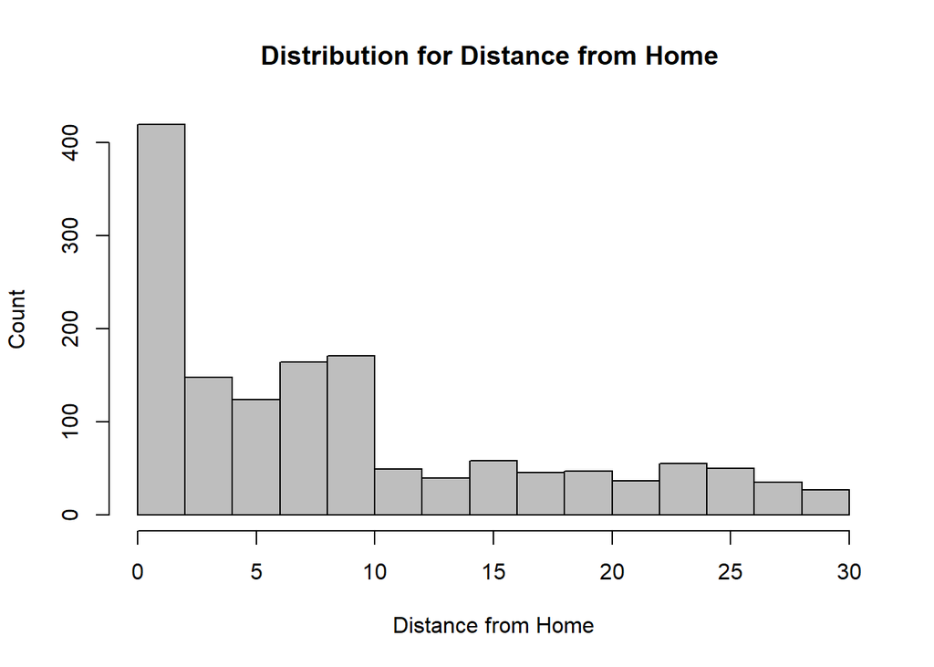

```r
hist(HR_data$DistanceFromHome,main="Distribution for Distance from Home ",xlab="Distance from Home",ylab="Count",col="grey")
```

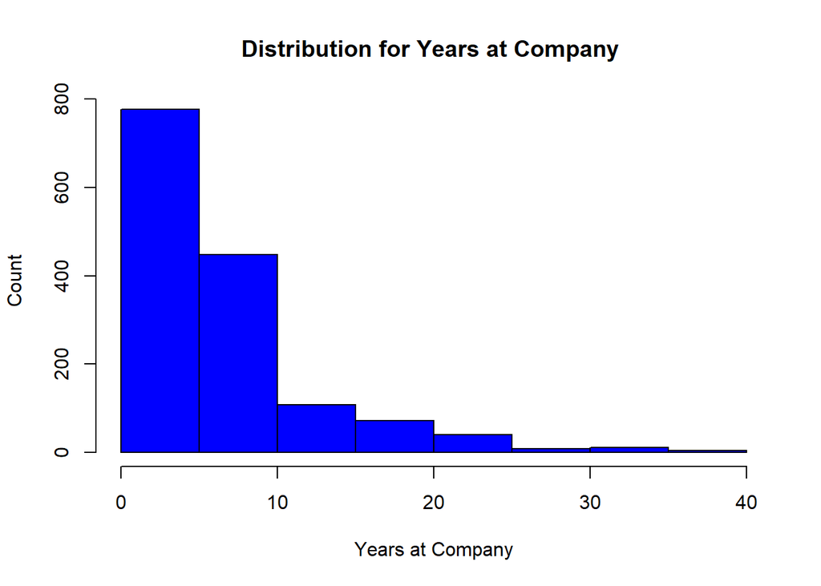

```r
hist(HR_data$YearsAtCompany,main="Distribution for Years at Company ",xlab="Years at Company",ylab="Count",col="blue")
```

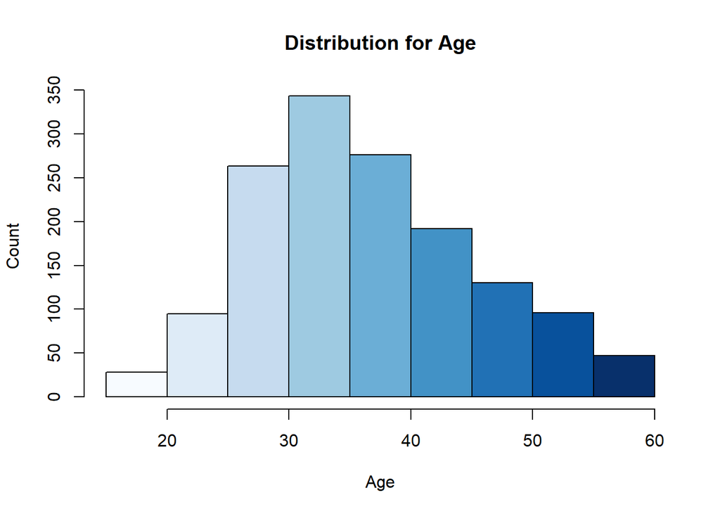

```r
hist(HR_data$Age,main="Distribution for Age",xlab="Age",ylab="Count",col=blues9)
```

```r
prop.table(table(HR_data$Gender)) #Percentage of Gender
```

```
##
## Female   Male
##    0.4    0.6
```

The table above show that 60% of the dataset gender is male.

Within our exploratory analysis, the Attrition column will be used as our target variable. Before continuing out analysis of the data, we should find out the distribution and percentage of the Attrition variable.

```r
library(dplyr)
library(magrittr)

HR_data %>% group_by(Attrition) %>% summarise(Total = n()) %>% print()
```

```
## # A tibble: 2 x 2
##   Attrition Total
##   <fct>     <int>
## 1 No         1233
## 2 Yes         237
```

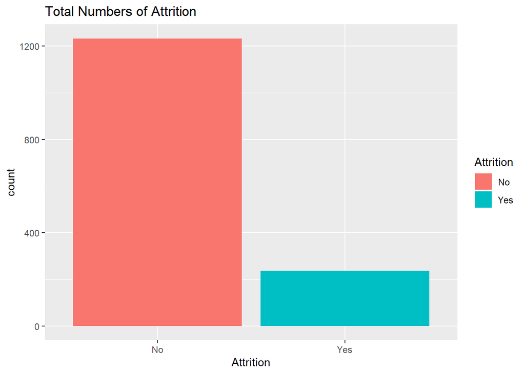

```r
library(ggplot2)

ggplot(HR_data,aes(Attrition,fill=Attrition))+geom_bar() + ggtitle("Total Numbers of Attrition")
```

```r
prop.table(table(HR_data$Attrition)) #Percentage of Attrition
```

```
##
##        No       Yes
## 0.8387755 0.1612245
```

From the table above, we see approximately 16% of IBM employees are leaving

Now that we have set the Attrition as our target variable, we can see how it affects the other variables in the dataset. In order to reduce time producing single graphs for these variables, we are going to use the `grid()` and `gridExtra()` functions to help arrange multiple grid-based plots on a page (Phiri, 2013).

```r
library(grid)
library(gridExtra)
```

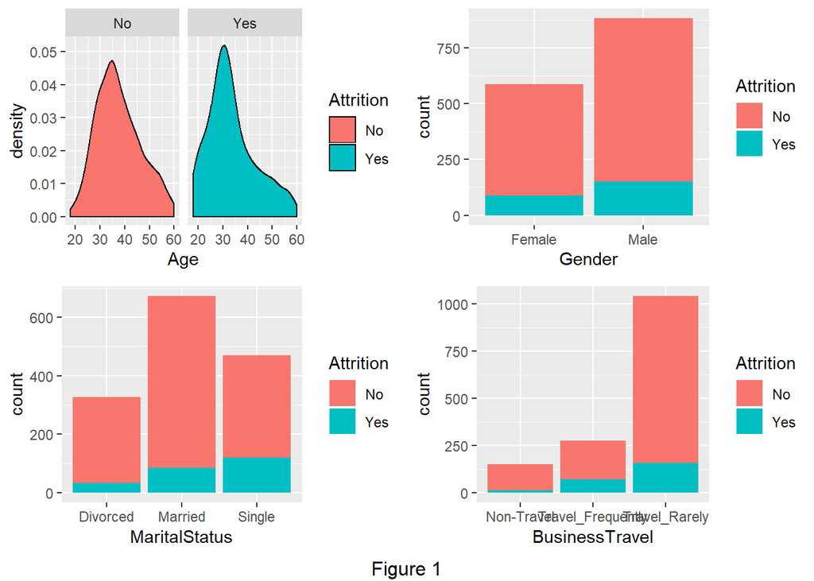

```r
age_graph <- ggplot(HR_data,aes(Age,fill=Attrition))+geom_density()+facet_grid(~Attrition)
gender_graph <- ggplot(HR_data,aes(Gender,fill=Attrition))+geom_bar()
marital_graph <- ggplot(HR_data,aes(MaritalStatus,fill=Attrition))+geom_bar()
business_graph <- ggplot(HR_data,aes(BusinessTravel,fill=Attrition))+geom_bar()
grid.arrange(age_graph,gender_graph,marital_graph,business_graph,ncol=2, bottom = "Figure 1")
```

In Figure 1, we see the following:

1. Age: Most employees that leave IBM are around 30 years old.
2. Gender: We see that majority of separated employees are Male and that is due to our dataset being comprised of 60% Male.
3. Marital Status: Employees that are Single show the highest signs of Attrition, while Divorced employees are the lowest.
4. Business Travel: Among employee who leave IBM, most travel.

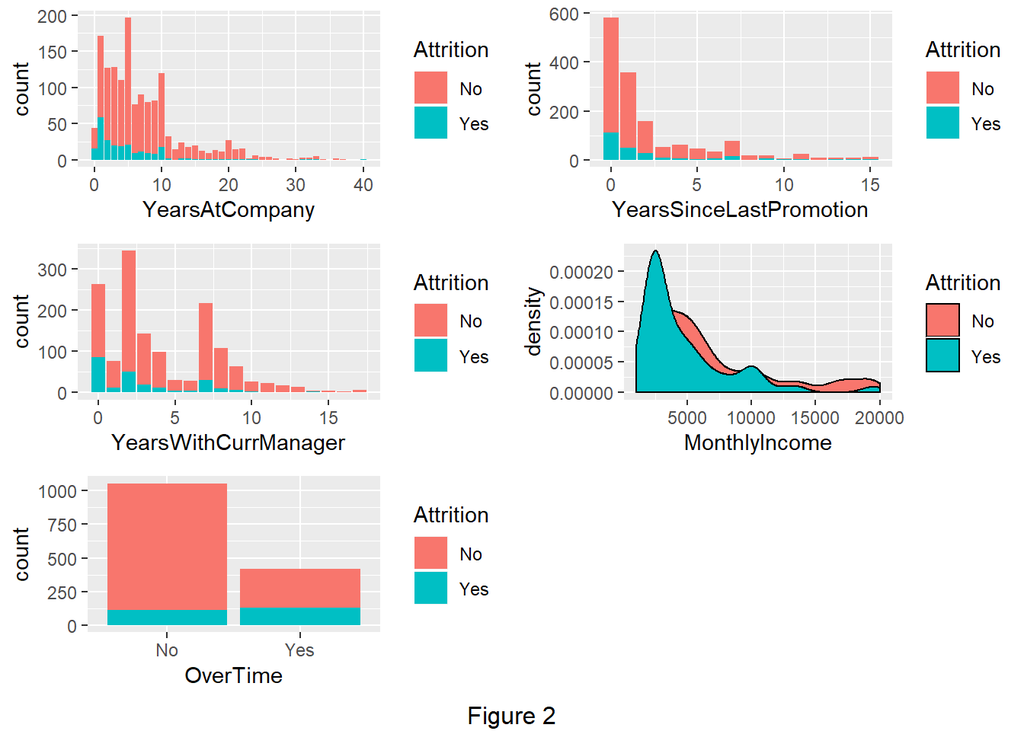

```r
YAC_graph <- ggplot(HR_data,aes(YearsAtCompany,fill = Attrition))+geom_bar()
YSP_graph <- ggplot(HR_data,aes(YearsSinceLastPromotion,fill = Attrition))+geom_bar()
YCM_graph <- ggplot(HR_data,aes(YearsWithCurrManager,fill = Attrition))+geom_bar()
MTHincome_graph <- ggplot(HR_data,aes(MonthlyIncome,fill=Attrition))+geom_density()
OT_graph<- ggplot(HR_data,aes(OverTime,fill=Attrition))+geom_bar()
grid.arrange(YAC_graph,YSP_graph,YCM_graph,MTHincome_graph,OT_graph,ncol=2, bottom = "Figure 2")
```

In Figure 2, we see the following:

5. Years at Company: Employees who have been with IBM for <3 years make up a larger proportion of those quitting the company.
6. Years Since Last Promotion: Employees that have been recently promoted are making up a larger proportion of those who quit IBM.
7. Years With Current Manager: Newly hired managers are also a reason for employees to quit.
8. Monthly Income: We see higher levels of attrition among the lower segment of monthly income.
9. Over Time: Employees who work overtime also have a larger proportion that are quitting.

### Preprocessing the Data

Before we start modelling the data, we should check if there are any missing values in the data which interfer which with the predictive model.

```r
sum(is.na(HR_data))
```

```
## [1] 0
```

We see that there are no missing values in the data after checking it, but we also would like to perform some data transformation. That is convert the type of some columns into a proper format.

```r
HR_data$Education <- as.factor(HR_data$Education)
HR_data$EnvironmentSatisfaction <- as.factor(HR_data$EnvironmentSatisfaction)
HR_data$JobInvolvement <- as.factor(HR_data$JobInvolvement)
HR_data$JobLevel <- as.factor(HR_data$JobLevel)
HR_data$JobSatisfaction <- as.factor(HR_data$JobSatisfaction)
HR_data$StockOptionLevel <- as.factor(HR_data$StockOptionLevel)
HR_data$PerformanceRating <- as.factor(HR_data$PerformanceRating)
HR_data$RelationshipSatisfaction <- as.factor(HR_data$RelationshipSatisfaction)
HR_data$WorkLifeBalance <- as.factor(HR_data$WorkLifeBalance)
```

Due to some columns only having a single value in their columns, we will remove them.

```r
HR_data <- HR_data %>% select(-EmployeeCount, -StandardHours, -Over18)
```

### Feature Engineering

Feature engineering can be defined as the science of extracting more information from existing data. This newly extracted information can be used as input to our prediction model (Bock, 2017). Thereby, creating the outcome to have more impact than the model. Now based on my assumptions, we can create two features with existing variables.

1. Tenure per job: People who worked at several companies but only for a short period time usually leave the company early maybe for a change of pace or building up enough experience through these companies to help them land a job at a major company.
2. Years without Change: People who went through role or job level changes probably enjoy the thought of taking on more responsible task as they gain seniority within a company. This variable will see the years a employee went without kind of change using the Role, Job Change and Promotion, as the metrics to determine change.

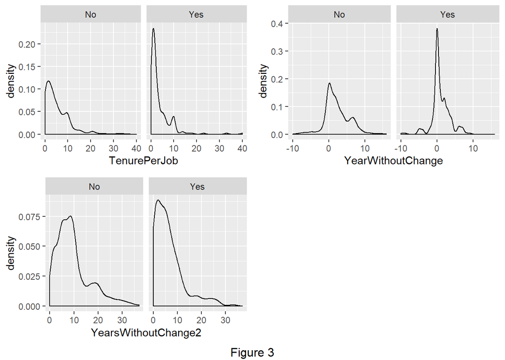

```r
HR_data_feng <- HR_data

HR_data_feng$TenurePerJob <- ifelse(HR_data_feng$NumCompaniesWorked!=0, HR_data_feng$TotalWorkingYears/HR_data_feng$NumCompaniesWorked,0)
HR_data_feng$YearWithoutChange <- HR_data_feng$YearsInCurrentRole - HR_data_feng$YearsSinceLastPromotion
HR_data_feng$YearsWithoutChange2 <- HR_data_feng$TotalWorkingYears - HR_data_feng$YearsSinceLastPromotion

TPJ_grapn <- ggplot(HR_data_feng,aes(TenurePerJob))+geom_density()+facet_grid(~Attrition)
YWC_graph <- ggplot(HR_data_feng,aes(YearWithoutChange))+geom_density()+facet_grid(~Attrition)
YWC2_graph <- ggplot(HR_data_feng,aes(YearsWithoutChange2))+geom_density()+facet_grid(~Attrition)
grid.arrange(TPJ_grapn,YWC_graph,YWC2_graph,ncol=2,bottom = "Figure 3")
```

In figure 3, we see that the Attrition variable does have an affect on these new features.

### Logistic Regression

Now we split the data into a 20% testing set and 80% training set with the `sample()` function which takes a vector as input; then you tell it how many samples to draw from that list (‘R Function’, 2019). We also use the`set.seed()` function which produces the same sample again and again. The purpose of creating two sets of data is so the training set is the one on which we train and fit our model basically to fit the parameters whereas test data is used only to assess performance of model (Shah, 2017).

```r
library(caret)
# Spliting the data
set.seed(18)
attr_training <- sample(nrow(HR_data), nrow(HR_data)*.8)
train_attr <- HR_data %>% slice(attr_training)
test_attr <- HR_data %>% slice(-attr_training)
```

```r
# Check the portion and percentage of Attrition in train data
table(train_attr$Attrition)
```

```
##
##  No Yes
## 996 180
```

```r
prop.table(table(train_attr$Attrition))
```

```
##
##        No       Yes
## 0.8469388 0.1530612
```

From the infomation displayed, we see that the data is imbalanced with Yes cases at 15%.However, we could to try to fix this imbalance sample by using up-sampling or down-sampling techniques. Keep in mind, there are pros and cons when using those techniques (Altini, 2015). With that in mind, we will try to make it balanced by using an upsampling technique with `ovun.sample()` function from ROSE package (Analytics, 2019).

```r
#install.packages("ROSE")
library(ROSE)
library(brglm2)
balanced_attr <- ovun.sample(Attrition ~ ., data = train_attr, method = "over",
                              N = 996*2, seed = 1)$data
table(balanced_attr$Attrition)
```

```
##
##  No Yes
## 996 996
```

After balancing the data, we will perform our first Logistic Regression model by using all the predictors in the formula.

```r
log_regress <- glm(Attrition ~ ., family = "binomial", data = balanced_attr)
summary(log_regress)
```

```
##
## Call:
## glm(formula = Attrition ~ ., family = "binomial", data = balanced_attr)
##
## Deviance Residuals:
##     Min       1Q   Median       3Q      Max
## -2.8672  -0.5173   0.0246   0.5847   3.4560
##
## Coefficients:
##                                    Estimate Std. Error z value Pr(>|z|)
## (Intercept)                      -9.801e+00  3.256e+02  -0.030 0.975983
## Age                              -3.858e-02  1.031e-02  -3.741 0.000183
## BusinessTravelTravel_Frequently   2.260e+00  3.203e-01   7.054 1.74e-12
## BusinessTravelTravel_Rarely       1.224e+00  2.896e-01   4.226 2.38e-05
## DailyRate                        -4.255e-04  1.751e-04  -2.429 0.015120
## DepartmentResearch & Development  1.521e+01  3.256e+02   0.047 0.962735
## DepartmentSales                   1.505e+01  3.256e+02   0.046 0.963137
## DistanceFromHome                  4.566e-02  8.898e-03   5.132 2.87e-07
## Education2                       -1.167e-02  2.495e-01  -0.047 0.962693
## Education3                       -9.487e-02  2.207e-01  -0.430 0.667304
## Education4                        2.541e-01  2.422e-01   1.049 0.294043
## Education5                        2.890e-01  4.320e-01   0.669 0.503559
## EducationFieldLife Sciences      -1.471e+00  6.599e-01  -2.229 0.025842
## EducationFieldMarketing          -6.816e-01  6.877e-01  -0.991 0.321555
## EducationFieldMedical            -1.346e+00  6.509e-01  -2.068 0.038676
## EducationFieldOther              -8.496e-01  6.986e-01  -1.216 0.223902
## EducationFieldTechnical Degree    1.691e-01  6.741e-01   0.251 0.801992
## EmployeeNumber                   -2.245e-04  1.224e-04  -1.834 0.066652
## EnvironmentSatisfaction2         -1.244e+00  2.258e-01  -5.509 3.60e-08
## EnvironmentSatisfaction3         -1.090e+00  2.059e-01  -5.296 1.18e-07
## EnvironmentSatisfaction4         -1.111e+00  2.029e-01  -5.473 4.41e-08
## GenderMale                        4.716e-01  1.448e-01   3.258 0.001124
## HourlyRate                       -1.655e-03  3.419e-03  -0.484 0.628366
## JobInvolvement2                  -1.240e+00  3.224e-01  -3.846 0.000120
## JobInvolvement3                  -1.580e+00  3.078e-01  -5.133 2.85e-07
## JobInvolvement4                  -1.678e+00  3.808e-01  -4.408 1.05e-05
## JobLevel2                        -1.025e+00  2.986e-01  -3.433 0.000596
## JobLevel3                         1.023e+00  5.256e-01   1.946 0.051666
## JobLevel4                        -2.091e+00  9.785e-01  -2.137 0.032572
## JobLevel5                         3.386e+00  1.189e+00   2.848 0.004400
```

[output cut: 94 more lines]

```
## WorkLifeBalance4                 .
## YearsAtCompany                   ***
## YearsInCurrentRole               ***
## YearsSinceLastPromotion          **
## YearsWithCurrManager             ***
## ---
## Signif. codes:  0 '***' 0.001 '**' 0.01 '*' 0.05 '.' 0.1 ' ' 1
##
## (Dispersion parameter for binomial family taken to be 1)
##
##     Null deviance: 2761.5  on 1991  degrees of freedom
## Residual deviance: 1511.3  on 1928  degrees of freedom
## AIC: 1639.3
##
## Number of Fisher Scoring iterations: 14
```

```r
glm(formula = Attrition ~ ., family = "binomial", data = train_attr,
    method = "detect_separation", linear_program = "dual")
```

```
## Separation: FALSE
## Existence of maximum likelihood estimates
##                      (Intercept)                              Age
##                             -Inf                                0
##  BusinessTravelTravel_Frequently      BusinessTravelTravel_Rarely
##                                0                                0
##                        DailyRate DepartmentResearch & Development
##                                0                              Inf
##                  DepartmentSales                 DistanceFromHome
##                              Inf                                0
##                       Education2                       Education3
##                                0                                0
##                       Education4                       Education5
##                                0                                0
##      EducationFieldLife Sciences          EducationFieldMarketing
##                                0                                0
##            EducationFieldMedical              EducationFieldOther
##                                0                                0
##   EducationFieldTechnical Degree                   EmployeeNumber
##                                0                                0
##         EnvironmentSatisfaction2         EnvironmentSatisfaction3
##                                0                                0
##         EnvironmentSatisfaction4                       GenderMale
##                                0                                0
##                       HourlyRate                  JobInvolvement2
##                                0                                0
##                  JobInvolvement3                  JobInvolvement4
##                                0                                0
##                        JobLevel2                        JobLevel3
##                                0                                0
##                        JobLevel4                        JobLevel5
##                                0                                0
##           JobRoleHuman Resources     JobRoleLaboratory Technician
##                              Inf                                0
##                   JobRoleManager    JobRoleManufacturing Director
##                                0                                0
##         JobRoleResearch Director        JobRoleResearch Scientist
##                                0                                0
##           JobRoleSales Executive      JobRoleSales Representative
##                                0                                0
```

[output cut: 12 more lines]

```
##        RelationshipSatisfaction3        RelationshipSatisfaction4
##                                0                                0
##                StockOptionLevel1                StockOptionLevel2
##                                0                                0
##                StockOptionLevel3                TotalWorkingYears
##                                0                                0
##            TrainingTimesLastYear                 WorkLifeBalance2
##                                0                                0
##                 WorkLifeBalance3                 WorkLifeBalance4
##                                0                                0
##                   YearsAtCompany               YearsInCurrentRole
##                                0                                0
##          YearsSinceLastPromotion             YearsWithCurrManager
##                                0                                0
## 0: finite value, Inf: infinity, -Inf: -infinity
```

The separation in the our model returned False so there extist no perfect separation

## References

Bendemra, H. (2019, March 11). Building an Employee Churn Model in Python to Develop a Strategic Retention Plan. Retrieved March 16, 2020, from https://towardsdatascience.com/building-an-employee-churn-model-in-python-to-develop-a-strategic-retention-plan-57d5bd882c2d

Law, R. (2019, May 28). Churn Rate: How High is Too High? A Meta-Analysis of Churn Studies. Retrieved April 07, 2020, from https://www.cobloom.com/blog/churn-rate-how-high-is-too-high

Kolowich, L. (2018, February 26). Why Are Your Employees Leaving The Organization (And How to Make Them Stay). Retrieved April 07, 2020, from https://blog.hubspot.com/agency/why-employees-leave

Ashe-Edmunds, S. (2017, November 21). Retention vs. Replacement for Employees. Retrieved April 07, 2020, from https://work.chron.com/retention-vs-replacement-employees-22865.html

Regan, R. (2020, March 17). 10 Clever Employee Retention Strategies in 2020. Retrieved April 07, 2020, from https://connecteam.com/employee-retention-strategies/

Quinn, M., & Waring, E. (2019, October 29). (Re)introducing skimr v2 - A year in the life of an open source R project - rOpenSci - open tools for open science. Retrieved April 08, 2020, from https://ropensci.org/blog/2019/10/29/skimrv2/

Phiri, L. (2013, February 13). Ggplot2 - Multiple Plots in One Graph Using gridExtra. Retrieved April 09, 2020, from https://lightonphiri.org/blog/ggplot2-multiple-plots-in-one-graph-using-gridextra

Bock, T. (2018, October 25). What is Feature Engineering? Retrieved April 10, 2020, from https://www.displayr.com/what-is-feature-engineering/

Xu, N. [Data Science Dojo]. (2018, January 24). Feature Engineering | Introduction to dplyr Part 4 [Video File]. Retrieved from https://youtu.be/nVnAcE-BGvA

Altini, M. (2015, August 17). Dealing with imbalanced data: undersampling, oversampling and proper cross-validation. Retrieved April 14, 2020, from https://www.marcoaltini.com/blog/dealing-with-imbalanced-data-undersampling-oversampling-and-proper-cross-validation

Analytics , V. (Ed.). (2019, June 24). Practical Guide to deal with Imbalanced Classification Problems in R. Retrieved April 14, 2020, from https://www.analyticsvidhya.com/blog/2016/03/practical-guide-deal-imbalanced-classification-problems/

Kuhn, M. (2019, March 27). The caret Package. Retrieved April 13, 2020, from https://topepo.github.io/caret/

R Function of the Day: sample. (2010, May 23). Retrieved April 16, 2020, from https://www.r-bloggers.com/r-function-of-the-day-sample-2/

Shah, T. (2017, December 10). About Train, Validation and Test Sets in Machine Learning. Retrieved April 14, 2020, from https://towardsdatascience.com/train-validation-and-test-sets-72cb40cba9e7

Sirohi, K. (2018, December 29). Simply Explained Logistic Regression with Example in R. Retrieved April 19, 2020, from https://towardsdatascience.com/simply-explained-logistic-regression-with-example-in-r-b919acb1d6b3

Kosmidis, I., & Schumacher, D. (2020, January 5). Detect/check for separation and infinite maximum likelihood estimates in logistic regression. Retrieved April 19, 2020, from https://cran.r-project.org/web/packages/detectseparation/vignettes/separation.html